# Dokumentacja projektu 2 faza 3

Ewa Baranowska, Dorota Łępicka, Michał Mück, Michał Stolarczyk

12 czerwca 2016

# Wstęp

Projekt ten miał na celu wyszukanie dni i zweryfikowanie powodu wzmożonej aktywności użytkowników na fanpage’u banków. Analizie poddaliśmy kilka banków: Alior Bank S.A., ING Bank Śląski oraz Bank Zachodni WBK. Dane które otrzymaliśmy były zbierane od czerwca 2013r. do lutego 2016r. Skupiliśmy się głównie na analizie rzeczowników. Posty nie zawierające rzeczowników zostały usunięte. Aby ułatwić pracę z danymi zbudowaliśmy ramkę danych zawierającą poniższe zmienne:

- id - id postu,
- parent_id - id nadrzędnego postu, jeśli taki nie istnieje jest brak danych,
- created_at - data utworzenia postu,
- tread_id - numer wątku do którego należy post,
- user_name - nazwa autora postu,
- body - treść postu,
- rzeczownik - rzeczowniki które znajdują się w poście zapisane w formie podstawowej.

Każdemu rzeczownikowi w poście został przydzielony osobny wiersz. Przykład takiej ramki danych:

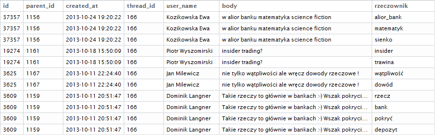

Aby umożliwić czytelnikowi odtworzenie wykonanych przez nas działań zbudowaliśmy pakiet o nazwie `ClockworkOranges`. Nasza biblioteka składa sie z:

1. funkcje:
- filterByPlotDF
- filterByPlotList
- finalDFrzecz
- poprawaOrtografii
- ramkaTylkoRzeczowniki
- separateNouns
- usuwanieStopwordsow
- wydobywanieRzeczownikow
- zamianaCzasownikow
2. zbiory danych wykorzystywane w funkcjach oraz testach:
- dane
- Alior
- AliorNouns
- datalist

Działanie oraz argumenty poszczególnych funkcji zostały szczegółowo opisane w dokumentacji pakietu. Natomiast ich przeznaczenie zostało omówione w następnych rozdziałach.

# Przetwarzanie danych

Jako dane wejściowe otrzymaliśmy ramkę danych zawierające informacje o wszystkich bankach. Przy pomocy funkcji `ramkaTylkoRzeczowniki()` wyodrębniliśmy z postów wszystkie rzeczowniki i zapisaliśmy je jako dodatkową kolumnę `rzeczownik` w formie rzeczownik1|rzeczownik2. Funkcja ta korzysta jeszcze z innych funkcji: `poprawaOrtografii()` przy pomocy której poprawiliśmy ortografię w kolumnie `body` zawierającej treści postów, oraz funkcji `wydobywanieRzeczownikow()` która wydobywa rzeczowniki ze zdania. Niestety w danych znajdują się jeszcze stopwordsy (np. a, oraz, to) i rzeczowniki odczasownikowe (np. pływać, spać). W tym celu powstała funkcja `finalDFrzecz()` korzystająca z funkcji `usuwanieStopwordsow()` oraz `zamianaCzasownikow()`. Usuwa ona niechciane wyrazy oraz poprawia pisownię rzeczowników odczasownikowych (pływać -> pływanie, spać -> spanie). Usunęliśmy również zbędne kolumny `subject`, `user_link` oraz `source`. Na otrzymanej w ten sposób ramce danych dodatkowo rozdzielamy rzeczowniki na osobne wiersze aby usprawnić działanie niektórych funkcji. Do tego celu służy funkcja `separateNouns()`.

# Kluczowe słowa

Za kluczowe słowa na które warto zwrócić uwagę uznaliśmy: `awaria`, `problem`, `reklamacja` oraz `błąd`. Przy pomocy funkcji `filterByPlotDF()` znajdujemy temat wątku, czyli rzeczownik występujący w co najmniej 50% postów. Aby dane słowo można było uznać za temat w wątku musi być co najmniej 5 postów.

# Wizualizacja danych

Do wizualizacji danych wykorzystaliśmy bibliotekę `shiny`. Po uruchomieniu aplikacji użytkownik widzi następującą stronę startową.

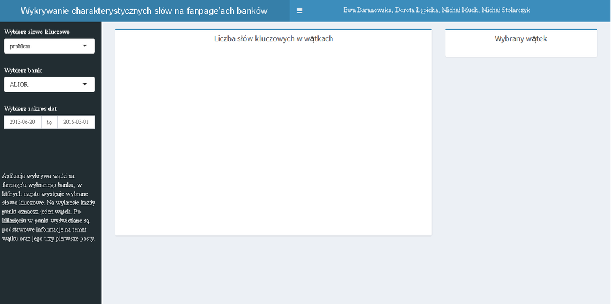

Po lewej stronie znajduje się menu na którym mamy możliwość wyboru kluczowego słowa, banku oraz zakresu dat dla których ma być rysowany wykres. Poniżej menu jest opis aplikacji.

Przykładowe wywołanie:

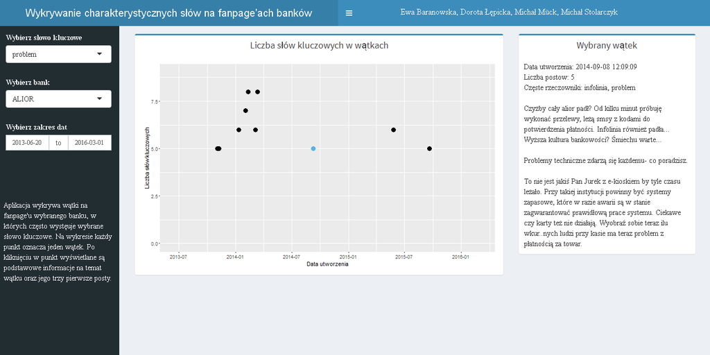

Po kliknięciu w punkt na wykresie po prawej stronie wyświetla się opis wybranego wątku. Dokładniej znajdziemy tutaj datę utworzenia wątku, liczbę postów, częste rzeczowniki oraz wypisane zostaną 3 pierwsze posty.

Aby powiększyć wykres i ukryć menu wystarczy kliknąć na znaczek $\equiv$ znajdujący się obok tytułu aplikacji. Aby powrócić do poprzedniego wyglądy należy ponownie nacisnąć ten przycisk.

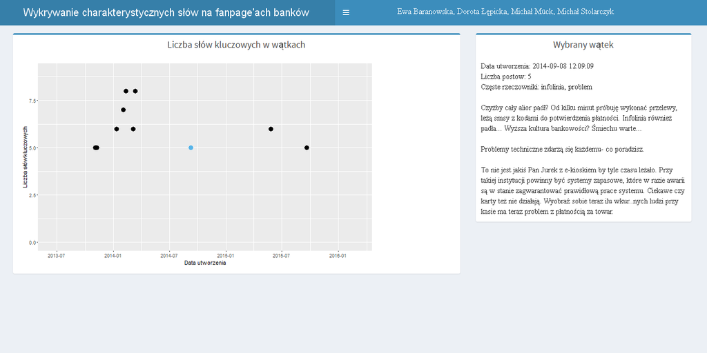

Podsumowując otrzymaliśmy proste i wygodne w użyciu narzędzie, w którym generujemy dużą ilość interaktywnych wykresów. Użytkownik z łatwością może zauważyć kiedy wystąpiły problemy w poszczególnym banku oraz dowiedzieć się czego dotyczył. Dla niektórych okresów czasu awarie występują we wszystkich bankach, być może problem ten powstał nie z winy banku.